# Rsa-uid4

Ben

11/24/2017

```r
library(doParallel)
library(dplyr)
library(ggplot2)
library(parallel)
library(rwebppl)
library(tidyr)
```

# Questions:

0. Do `speakers` prefer marked utterances to unmarked as a function of need probability (`p(w_i)`)
1. Do `listener` generate an “um” implicature – interpret an utterance “X” as the high suprisal item.

## Parameters

- `model` (S1DV vs L0D vs L2DVVDV, etc.)
- `need probabilities`
- `input` (speakers take worlds, listeners take utterances)
- `theta` noise level

```r
modelFile <- "/Users/benpeloquin/Desktop/Projects/rsa_uid/Models/rsa-uid-MF-effects.wppl"
BASE.MODEL <- readChar(modelFile, file.info(modelFile)$size)
```

```r
modelCombs <- function(prefix, items, n) {
  affixes <- unique(combn(rep(items, n), m=n, FUN=function(x) paste(x, collapse='')))
  sapply(affixes, function(x) paste0(prefix, x))
}

listenerModels <- c(
  modelCombs('L0', c('D', 'V'), 1),
  modelCombs('L1', c('D', 'V'), 3))

speakerModels <- c(
  modelCombs('S1', c('D', 'V'), 2),
  modelCombs('S2', c('D', 'V'), 4))

variableNeedProbs <- "
var worldDistr = Categorical({
  vs:[{color:'a'}, {color:'b'}, {color:'c'}, {color:'d'}, {color:'e'}],
  ps:[0.1, 0.3, 0.5, 0.7, 1]
})
"

uniformNeedProbs <- "
var worldDistr = Categorical({
  vs:[{color:'a'}, {color:'b'}, {color:'c'}, {color:'d'}, {color:'e'}],
  ps:[1, 1, 1, 1, 1]
})
"
```

# Preference for high semantic suprisal items

```r
buildCompleteModel <- function(needProbs) {
  completeModelStr <- paste(needProbs, BASE.MODEL)
  completeModelStr
}

run <- function(modelName, input, needProbs, needType, theta, alpha=1) {
  completeModelStr <- buildCompleteModel(needProbs)
  isSpeakerExp <- unlist(strsplit(modelName, ''))[1] == 'S'
  isVariableNeeds <- needProbs
  rData <- data.frame(modelName=modelName, theta=theta, input=input, isSpeakerExp=isSpeakerExp, alpha=alpha)
  d <- webppl(completeModelStr, data=rData, data_var='rData') %>%
    mutate(input=input,
           theta=theta,
           modelType=modelName,
           isSpeaker=isSpeakerExp,
           needType=needType,
           alpha=alpha)
  d
}
```

```r
runExp1 <- function(modelName) {
  nRuns <- 10
  combs <- 4
  models <- rep(modelName, nRuns*combs)
  inputs <- c(rep('a', nRuns), rep('e', nRuns), rep('b', nRuns), rep('c', nRuns))
  needProbs <- rep(variableNeedProbs, nRuns*combs)
  needProbTypes <- rep('variable', nRuns*combs)
  alphas <- rep(2, nRuns*combs)
  thetas <- rep(seq(0.1, 0.9, length.out=nRuns), combs)

  dRuns <- mapply(run, models, inputs, needProbs, needProbTypes, thetas, alphas, SIMPLIFY=FALSE)
  df <- do.call(rbind, dRuns)
  rownames(df) <- 1:nrow(df)
  df
}
```

# Question 1: Do `speakers` prefer marked utterances to unmarked as a function of need probability (`p(w_i)`)

```r
ptm <- proc.time()
df1a <- runExp1('S2DVDV')
cat('runtime: ', (proc.time() - ptm)[3]/60)
```

```
## runtime:  2.718367
```

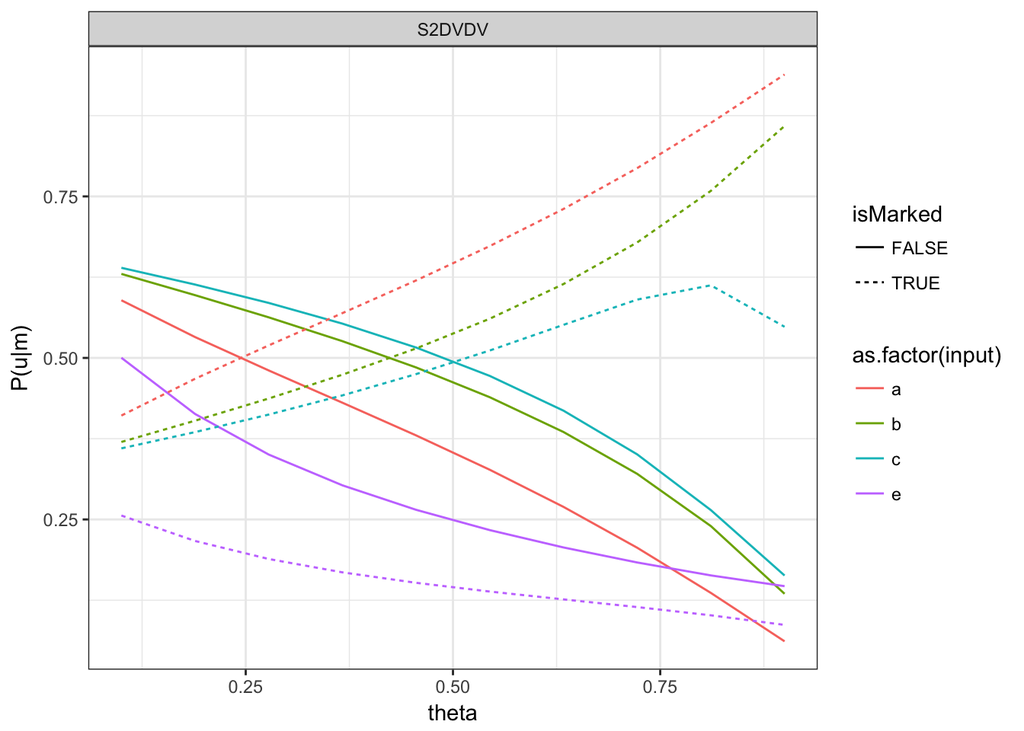

```r
df1a %>%
  mutate(support=as.character(support),
         isMarked=substring(support, 1, 1) == 'X',
         isPrimaryCompare=ifelse(input=='a', support %in% c('X a', 'a'),
                                 ifelse(input=='e', support %in% c('X e', 'e'),
                                        ifelse(input=='b', support %in% c('X b', 'b'),
                                               ifelse(input=='c', support %in% c('X c', 'c'), FALSE))))) %>%
  filter(isPrimaryCompare) %>%
  ggplot(aes(x=theta, y=prob, col=as.factor(input))) +
    geom_line(aes(lty=isMarked)) +
    ylab("P(u|m)") +
    facet_grid(~modelType) +
    theme_bw()
```

## Varying `alpha` and theta, hodling model `S1DV` constant.

```r
runExp1b <- function(modelName) {
  nRuns <- 10
  combs <- 4
  models <- rep(modelName, nRuns*combs)
  inputs <- c(rep('a', nRuns*2), rep('e', nRuns*2))
  needProbs <- rep(variableNeedProbs, nRuns*combs)
  needProbTypes <- rep('variable', nRuns*combs)
  alphas <- rep(c(rep(1, nRuns), rep(3, nRuns)), 2)
  thetas <- rep(seq(0.1, 0.9, length.out=nRuns), combs)

  dRuns <- mapply(run, models, inputs, needProbs, needProbTypes, thetas, alphas, SIMPLIFY=FALSE)
  df <- do.call(rbind, dRuns)
  rownames(df) <- 1:nrow(df)
  df
}
```

```r
df1b <- runExp1b('S1DV')
```

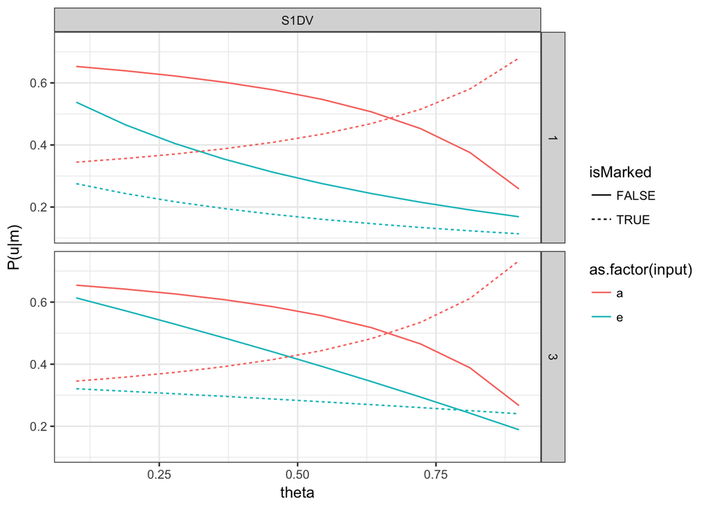

```r
df1b %>%
  mutate(support=as.character(support),
         isMarked=substring(support, 1, 1) == 'X',
         isPrimaryCompare=ifelse(input=='a', support %in% c('X a', 'a'),
                                 ifelse(input=='e', support %in% c('X e', 'e'),
                                        ifelse(input=='b', support %in% c('X b', 'b'),
                                               ifelse(input=='c', support %in% c('X c', 'c'), FALSE))))) %>%
  filter(isPrimaryCompare) %>%
  ggplot(aes(x=theta, y=prob, col=as.factor(input))) +
    geom_line(aes(lty=isMarked)) +
    ylab("P(u|m)") +
    facet_grid(alpha~modelType) +
    theme_bw()
```

### (Analytically) reproducing Levy & Jaeger (2007) Figure 1.

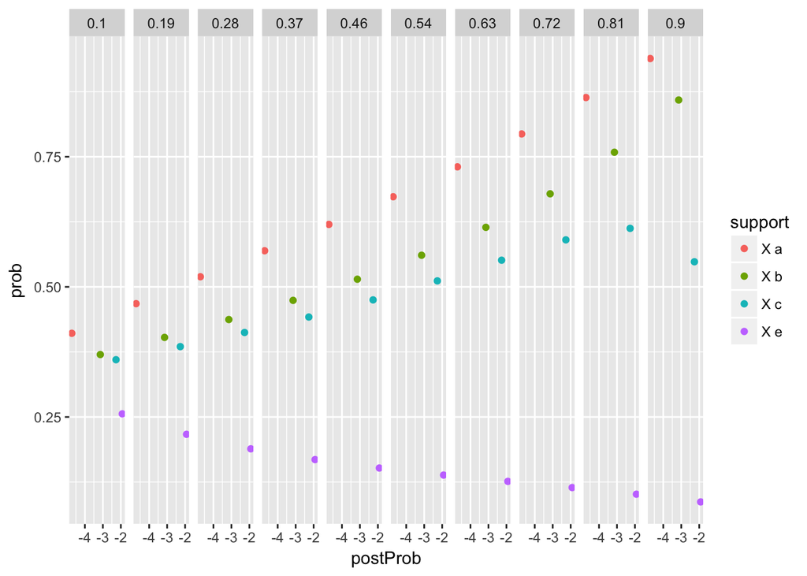

```r
worldDistr <- c(0.1, 0.3, 0.55, 0.7, 1)
worldDistr <- worldDistr / sum(worldDistr)


df1a %>%
  mutate(roundTheta=round(theta, digits=2),
         support=as.character(support),
         isMarked=substring(support, 1, 1) == 'X',
         isPrimaryCompare=ifelse(input=='a', support %in% c('X a', 'a'),
                                 ifelse(input=='e', support %in% c('X e', 'e'),
                                        ifelse(input=='b', support %in% c('X b', 'b'),
                                               ifelse(input=='c', support %in% c('X c', 'c'), FALSE))))) %>%
  group_by(input) %>%
  mutate(uncondProb=ifelse(input=='a', worldDistr[1],
                           ifelse(input=='b', worldDistr[2],
                                  ifelse(input=='c', worldDistr[3], worldDistr[4]))),
         postProb=log2(uncondProb),
         marked=ifelse(support %in% sapply(letters[1:5], function(x) paste('X', x)), 'marked', 'unmarked')) %>%
  ungroup %>%
  filter(isPrimaryCompare, isMarked) %>%
  ggplot(aes(x=postProb, y=prob, col=support)) +
    geom_point() +
    facet_grid(~roundTheta)
```

UID predicts `P(marked version|{color: a}) >> P(marked version|{color: e})`.

## Varying model

- recursive depth
- noise awareness (`D` noise, `V`: no noise)
- `S1DV` – S1 speaker considers noise, L0 listener doesn’t consider noise …
- `S2DVDV` – S2 speaker considers noise, L1 doesn’t, S1 consider noise, L0 doesn’t

```r
no_cores <- detectCores() - 1
cl <- makeCluster(no_cores)
registerDoParallel(cl)
```

```r
models <- c('S1DD', 'S1DV', 'S1VV', 'S2DVDV', 'S2DDDD', 'S2VVVV', 'S2DVVV')
ptm <- proc.time()
dSims <- foreach(m=models, .combine=rbind, .packages=c('dplyr', 'rwebppl')) %dopar% runExp1(m)
stopCluster(cl)
etm <- proc.time() - ptm
cat("runtime: ", etm[3] / 60)
```

```
## runtime:  9.166083
```

```r
# dfS1DD <- runExp1('S1DD')
# dfS1DV <- runExp1('S1DV')
# dfS1VV <- runExp1('S1VV')
# dfS2DVDV <- runExp1('S2DVDV')
# dfS2DDDD <- runExp1('S2DDDD')
# dfS2VVVV <- runExp1('S2VVVV')
# dfAgg <- rbind(dfS1DD, dfS1VD, dfS1VV, dfS2DVDV, dfS2DDDD, dfS2VVVV)
```

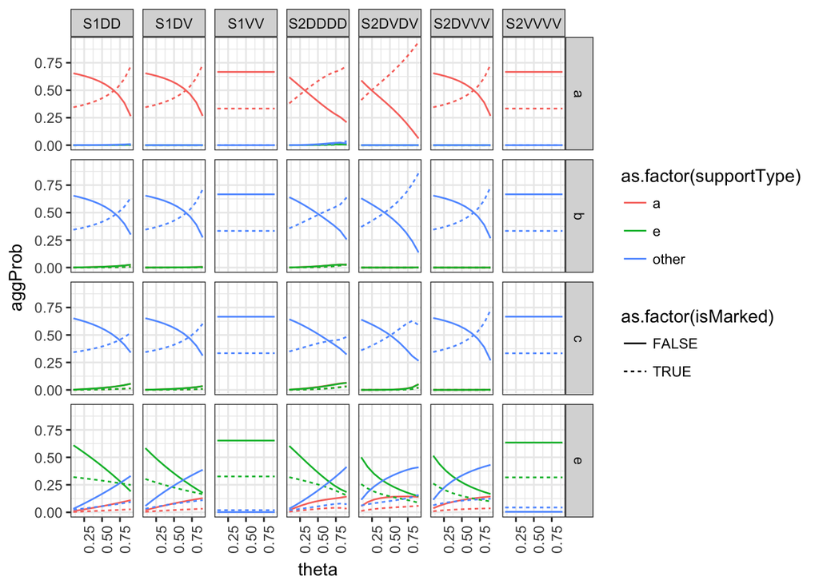

```r
dSims %>%
  mutate(support=as.character(support),
         isMarked=substring(support, 1, 1) == 'X',
         isPrimaryCompare=ifelse(input=='a', support %in% c('X a', 'a'), support %in% c('X e', 'e')),
         supportStr=ifelse(support %in% c('X a', 'a', 'X e', 'e'), support, 'other')) %>%
  group_by(modelType, input, theta, supportStr, isMarked, isPrimaryCompare) %>%
  summarise(aggProb=sum(prob)) %>%
  mutate(supportType=ifelse(supportStr %in% c('X a', 'a'), 'a', ifelse(supportStr %in% c('X e', 'e'), 'e', 'other'))) %>%
  ungroup %>%
ggplot(aes(x=theta, y=aggProb, col=as.factor(supportType), lty=as.factor(isMarked))) +
  geom_line() +
  facet_grid(input~modelType) +
  theme_bw() +
  theme(axis.text.x=element_text(angle=90, hjust=1),
          plot.title=element_text(hjust=0.5, size=14))
```

### Interim summary

*Do speakers prefer marked versions as noise increases? Yes.*

- At least one speaker must be aware of noise.
- Higher-order speakers respond more quickly to noise than lower-order (propogation of noise?)
- Including listener noise reduces posterior prob of marked version (see difference between `S1DV` and `S1DD`, `S2DDDD` and `S2DVDV`)

# Question 2 Do `listener` generate an “um” implicature – interpret an utterance “X” as the high suprisal item.

```r
runExp2 <- function(modelName) {
  nRuns <- 10
  models <- rep(modelName, nRuns*4)
  inputs <- c(rep('a', nRuns), rep('X a', nRuns), rep('e', nRuns), rep('X e', nRuns))
  needProbs <- rep(variableNeedProbs, nRuns*4)
  needProbTypes <- rep('variable', nRuns*4)
  thetas <- rep(seq(0.1, 0.9, length.out=nRuns), 4)
  alphas <- rep(20, nRuns*4)

  dRuns <- mapply(run, models, inputs, needProbs, needProbTypes, thetas, alphas, SIMPLIFY=FALSE)
  df <- do.call(rbind, dRuns)
  rownames(df) <- 1:nrow(df)
  df
}
```

```r
ptm <- proc.time()
df2 <- runExp2('L1VDV')
cat('runtime: ', (proc.time() - ptm)[3]/60)
```

```
## runtime:  1.190917
```

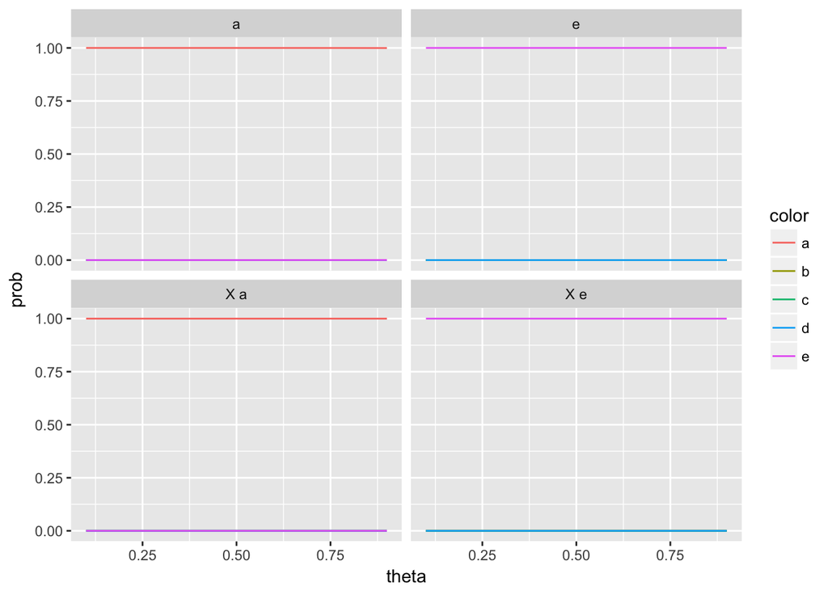

```r
df2 %>%
  ggplot(aes(x=theta, y=prob, col=color)) +
    geom_line() +
    facet_wrap(~input)
```

### Um implicature - single model

```r
runExp3 <- function(modelName) {
  nRuns <- 10
  models <- rep(modelName, nRuns)
  inputs <- rep('X', nRuns)
  needProbs <- rep(variableNeedProbs, nRuns)
  needProbTypes <- rep('variable', nRuns)
  thetas <- seq(0.1, 0.9, length.out=nRuns)
  alphas <- rep(10, nRuns)

  dRuns <- mapply(run, models, inputs, needProbs, needProbTypes, thetas, alphas, SIMPLIFY=FALSE)
  df <- do.call(rbind, dRuns)
  rownames(df) <- 1:nrow(df)
  df
}
```

```r
ptm <- proc.time()
df3 <- runExp3('L1VDD')
cat('runtime: ', (proc.time() - ptm)[3]/60)
```

```
## runtime:  0.3396667
```

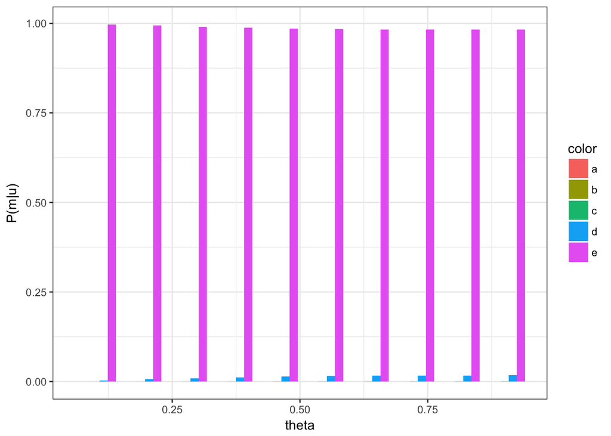

```r
df3 %>%
  ggplot(aes(x=theta, y=prob, fill=color)) +
    geom_bar(stat='identity', position='dodge') +
    theme_bw() +
    ylab('P(m|u)')
```

For `L1VDD` the posterior strongly reflectsion the semantic prior over worlds.

### Um implicature - varying model, varying need probs.

```r
# model <-'L2DDDVV'
# model <-'L2DDVVV'
model <-'L2VVVDD'

variableNeedProbs10 <- "
var worldDistr = Categorical({
  vs:[{color:'a'}, {color:'b'}, {color:'c'}, {color:'d'}, {color:'e'}],
  ps:[0.1, 1, 1, 1, 1]
})
"

variableNeedProbs50 <- "
var worldDistr = Categorical({
  vs:[{color:'a'}, {color:'b'}, {color:'c'}, {color:'d'}, {color:'e'}],
  ps:[0.50, 1, 1, 1, 1]
})
"

variableNeedProbs85 <- "
var worldDistr = Categorical({
  vs:[{color:'a'}, {color:'b'}, {color:'c'}, {color:'d'}, {color:'e'}],
  ps:[0.85, 1, 1, 1, 1]
})
"
```

```r
runExp4 <- function(modelName) {
  nRuns <- 10
  combs <- 3
  models <- rep(modelName, nRuns * combs)
  inputs <- rep('X', nRuns * combs)
  needProbs <- c(rep(variableNeedProbs10, nRuns), rep(variableNeedProbs50, nRuns), rep(variableNeedProbs85, nRuns))
  needProbTypes <- c(rep('variableNeedProbs10', nRuns), rep('variableNeedProbs50', nRuns), rep('variableNeedProbs85', nRuns))
  thetas <- rep(seq(0.1, 0.9, length.out=nRuns), combs)
  alphas <- rep(10, nRuns*combs)

  dRuns <- mapply(run, models, inputs, needProbs, needProbTypes, thetas, alphas, SIMPLIFY=FALSE)
  df <- do.call(rbind, dRuns)
  rownames(df) <- 1:nrow(df)
  df
}
```

```r
timeFn <- function(fn) {
  return(function(x) {
    ptm <- proc.time()
    res <- fn(x)
    etm <- proc.time() - ptm
    cat("runtime: ", etm[3] / 60)
    res
  })
}
timeRunExp4 <- timeFn(runExp4)
df4 <- timeRunExp4(model)
```

```
## runtime:  9.4756
```

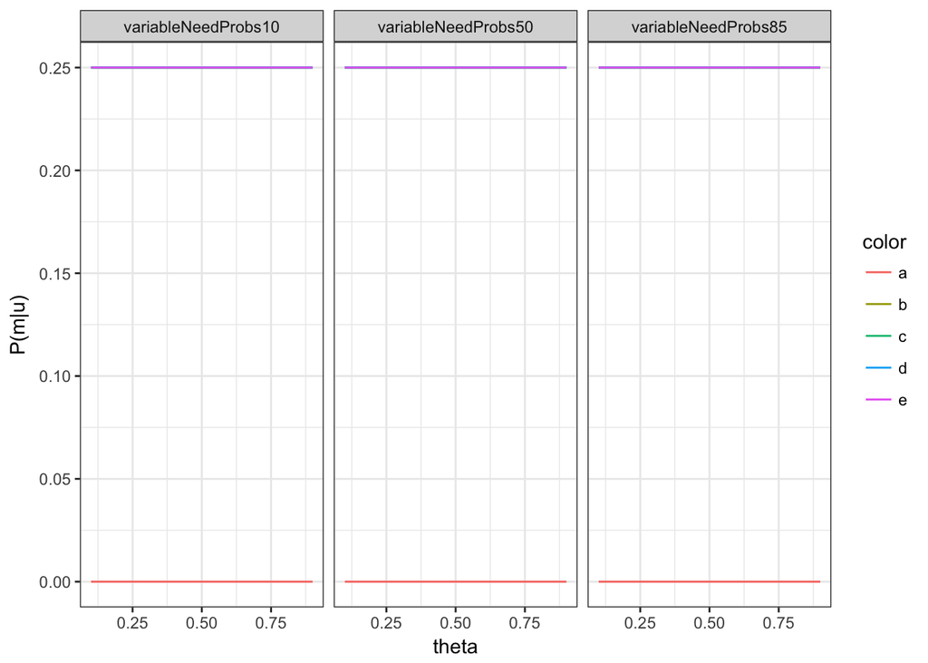

```r
df4 %>%
  ggplot(aes(x=theta, y=prob, col=color)) +
    # geom_bar(stat='identity', position='dodge') +
    geom_line() +
    theme_bw() +
    ylab('P(m|u)') +
    facet_grid(~needType)
```

```r
# par setup
no_cores <- detectCores() - 1
cl <- makeCluster(no_cores)
registerDoParallel(cl)

# run
models <- c('L2DDVVV', 'L2DDDVV', 'L2VVVDD')
ptm <- proc.time()
dSims5 <- foreach(m=models, .combine=rbind, .packages=c('dplyr', 'rwebppl')) %dopar% runExp4(m)
stopCluster(cl)
etm <- proc.time() - ptm
cat("runtime: ", etm[3] / 60)
```

```
## runtime:  12.93077
```

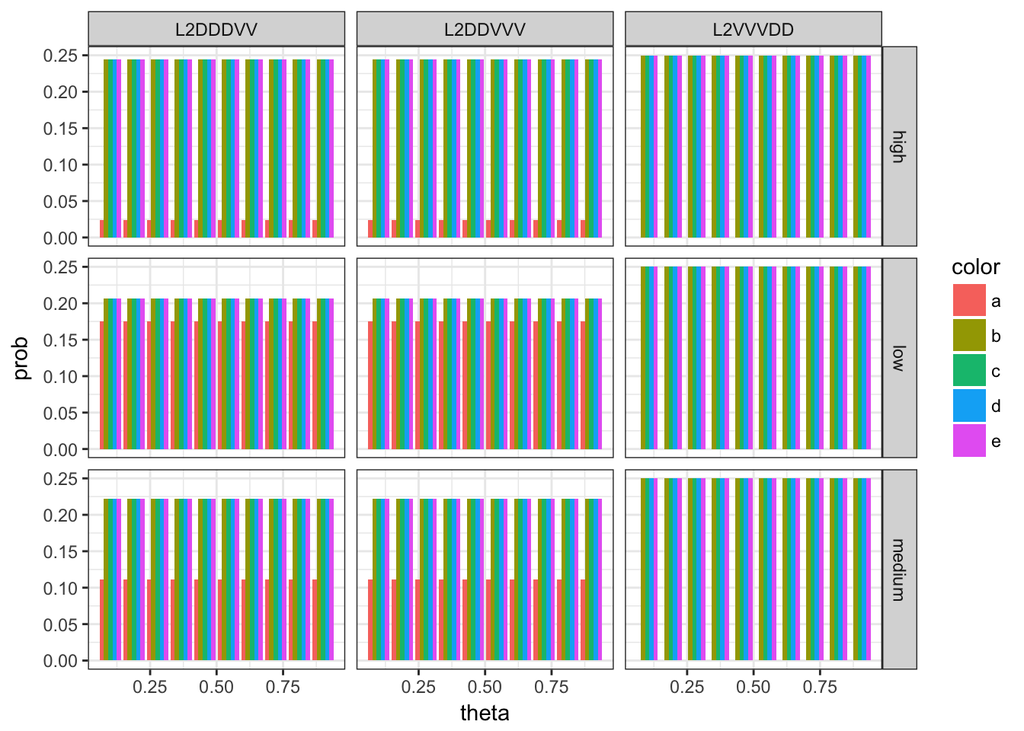

```r
dSims5 %>%
  mutate(semSurprisal=ifelse(needType=='variableNeedProbs10', 'high', ifelse(needType=='variableNeedProbs50', 'medium', 'low'))) %>%
  ggplot(aes(x=theta, y=prob, fill=color)) +
    geom_bar(stat='identity', position='dodge') +
    facet_grid(semSurprisal~modelType) +
    theme_bw()
```

### Interim summary

*Do listeners make infer that ‘X’ refers to the high surprisal item? No.*